# Softmax

### **NOTES ON STATISTICS, PROBABILITY and MATHEMATICS**

### Softmax Activation:

This is a good [resource](http://eli.thegreenplace.net/2016/the-softmax-function-and-its-derivative/).

In multiclass classification networks the softmax function:

The last hidden layer produces output values forming a vector $\vec x = \mathbf x$. The output neuronal layer is meant to classify among $K=1,\dots,k$ categories with a SoftMax activation function assigning conditional probabilities (given $\mathbf x$) to each one the $K$ categories. In each node in the final (or ouput) layer the pre-activated values (logit values) will consist of the scalar products $\mathbf{w}_j^\top\mathbf{x}$, where $\mathbf w_j\in\{\mathbf{w}_1, \mathbf{w}_2,\dots,\mathbf{w}_k\}$. In other words, each category, $k$ will have a different vector of weights pointing at it, determining the contribution of each element in the output of the previous layer (including a bias), encapsulated in $\mathbf x$. However, the activation of this final layer will not take place element-wise (as for example with a sigmoid function in each neuron), but rather through the application of a SoftMax function, which will map a vector in $\mathbb R^k$ to a vector of $K$ elements in $[0,1]$. Here is a made-up NN to classify colors:

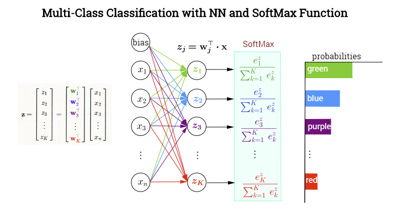

The softmax as

$$\sigma(j)=\frac{\exp(\mathbf{w}_j^\top
\mathbf x)}{\sum_{k=1}^K \exp(\mathbf{w}_k^\top\mathbf
x)}=\frac{\exp(z_j)}{\sum_{k=1}^K \exp(z_k)}$$

This will result in a normalization of the output adding up to $1$, interpretable as a probability mass functionn.

From Wikipedia:

```
"In probability theory, the output of the softmax function can be used to represent a categorical distribution – that is, a probability distribution over K different possible outcomes."
```

Notice that there is truly no strict need for an activation function. As in [this post](https://www.quora.com/What-is-the-benefit-of-using-softmax-function-in-the-last-layer-of-DNN-What-is-the-relation-between-cross-entropy-and-loss-functions?srid=utSnl):

```
"At the end of a network, you can either use nothing (logits) and get a multi parameter regression."
```

So why do it?

#### [Advantages](http://eli.thegreenplace.net/2016/the-softmax-function-and-its-derivative/):

1. softmax is optimal for maximum-likelihood estimation of the model parameters.
2. The properties of softmax (all output values in the range (0, 1) and sum up to 1.0) make it suitable for a probabilistic interpretation that’s very useful in machine learning.
3. Softmax normalization is a way of reducing the influence of extreme values or outliers in the data without removing data points from the set.

Although we can use mean squared error, [cross-entropy is the preferred loss function](https://www.quora.com/Is-the-softmax-loss-the-same-as-the-cross-entropy-loss?srid=utSnl) for classification NN with softmax activation in the last layer. It is given by the function:

$$\begin{eqnarray}
C = -\frac{1}{k} \sum_{k=1}^K \left[y_k \log (\sigma(z_k)) + (1-y_k )
\log (1-\sigma(z_k)) \right]
\end{eqnarray}$$

As explained [here](https://jamesmccaffrey.wordpress.com/2013/11/05/why-you-should-use-cross-entropy-error-instead-of-classification-error-or-mean-squared-error-for-neural-network-classifier-training/), average cross-entropy (ACE) would be calculated as:

```
computed       | targets              | correct?
-----------------------------------------------
0.3  0.3  0.4  | 0  0  1 (democrat)   | yes
0.3  0.4  0.3  | 0  1  0 (republican) | yes
0.1  0.2  0.7  | 1  0  0 (other)      | no
```

$$-\left( (\log(0.3)\times 0) + (\log
(0.3)\times 0) + (\log (0.4)\times1) \right) = -\log(0.4)$$

With one-hot encoding, the $y$ vector will eliminate all elements, except for one (the correct value for the example). The expression $y_k\log \hat y_k + (1-y_k)\log(1-\hat y_k)$ will become $\log \hat y_k$ so that if the calculated probability for that category is close to $1$, the loss function will approach zero, whereas, if the probabily (output of the softmax for that category) is close to zero, the loss will tend to infinity.

##### Derivative of the softmax function with respect to the logit $(z_j =\mathbf W_j^\top \cdot \mathbf x)$:

$$\frac{\partial}{\partial
z_i}\sigma(j)=\frac{\partial}{\partial z_i}\frac{\exp(z_j)}{\sum_{k=1}^K
\exp(z_k)}$$

The derivative of $\sum_{k=1}^K \exp(z_k)$ with respect to any $z_i$ will be $\exp(z_i)$. As for the numerator, $\exp(z_j)$ the derivative will be $\exp(z_i)$ if and only if $z_i = z_j$; otherwise the derivative is $0$.

If $i = j$, and using the quotient rule,

$$\begin{align}\frac{\partial}{\partial
z_i}\frac{\exp(z_j)}{\sum_{k=1}^K \exp(z_k)}
&=
\frac{\mathbf \exp(z_j)\sum_{k=1}^K \exp(z_k)\quad -
\exp(z_i)\exp(z_j)}{\left[\sum_{k=1}^K \exp(z_k)\right]^2}\\[2ex]
&=
\frac{\exp(z_j)}{\sum_{k=1}^K \exp(z_k)}\frac{\sum_{k=1}^K
\exp(z_k)-\exp(z_i)}{\sum_{k=1}^K \exp(z_k)}\\[2ex]
&=\sigma(z_j)\,(1 - \sigma(z_i))
\end{align}$$

If on the other hand, $i \neq j$:

$$\begin{align}\frac{\partial}{\partial
z_i}\frac{\exp(z_j)}{\sum_{k=1}^K \exp(z_k)}
&= \frac{0\quad - \exp(z_i)\exp( z_j)}{\left[\sum_{k=1}^K
\exp(z_k)\right]^2}\\[2ex]
&= -
\frac{\exp(z_j)}{\sum_{k=1}^K \exp(z_k)}\frac{\exp(z_i)}{\sum_{k=1}^K
\exp(z_k)}\\[2ex]
&=-\sigma(z_j)\,\sigma(z_i)
\end{align}$$

These two scenarios can be brought together as

$$\frac{\partial}{\partial z_i}
\sigma(z_j)=
\sigma(z_j)\left(\delta_{ij}-\sigma(z_i)\right)$$

[MIT Deep Learning book](http://www.deeplearningbook.org/contents/TOC.html)

[Home Page](http://rinterested.github.io/statistics/index.html)

**NOTE: These are tentative notes on different topics for personal use - expect mistakes and misunderstandings.**